# Constraste de Hipótesis

Javier Cara

Noviembre-Diciembre 2018

# 1 Contraste de hipótesis para la media de la distribución normal

## 1.1 Planteamiento del problema

Se va a construir un puente de hormigón con resistencia a compresión igual a 60 N/mm2. Para comprobar que se cumplen las especificaciones del proyecto se toman al azar 15 probetas, obteniendo las siguientes resistencias a compresión (N/mm2):

40.15, 65.10, 49.50, 22.40, 38.20, 60.40, 43.40, 26.35, 31.20, 55.60, 47.25, 73.20, 35.90, 45.25, 52.40

Comprobar si el hormigón con el que se está construyendo el puente es adecuado o no.

## 1.2 Hipótesis nula e hipótesis alternativa

- Consideramos que la resistencia a compresión del hormigón es una variable aleatoria con distribución $X \sim N(\mu, \sigma^2$).
- La media y la desviación típica muestrales son:

```r
# muestra
muestra = c(40.15, 65.10, 49.50, 22.40, 38.20, 60.40, 43.40, 26.35, 31.20, 55.60, 47.25, 73.20, 35.90, 45.25, 52.40)

# media muestral
( xm = mean(muestra) )
```

```
## [1] 45.75333
```

```r
# desviación tipica muestral
( s = sd(muestra) )
```

```
## [1] 14.20399
```

- Como la media muestral es inferior a 60 sospechamos que el hormigón del puente tiene una resistencia inferior a 60. Pero queremos comprobar *estadísticamente* que esa diferencia no se debe al caracter aleatorio de las medidas.
- En términos estadísticos, el problema se formula mediante una hipótesis nula ($H_0$) y una hipótesis alternativa ($H_1$):

$$\begin{align}
H_0 \ & : \ \mu = 60 \\
H_1 \ & : \ \mu < 60
\end{align}$$

## 1.3 Solución del contraste

Sabemos que el estimador de $\mu$ es la media muestral y que tiene distribución:

$$\frac{\bar X - \mu}{S/\sqrt{n}} \sim t_{n-1}$$

- Vamos a suponer que la hipótesis nula es cierta y comprobaremos que las conclusiones que se obtienen son acordes con esta suposición. En caso contrario, aceptamos que la hipótesis nula no es cierta (es como reduccion al absurdo en matematicas).
- Supongamos $H_0$ cierta, es decir, $\mu = 60$. Entonces:

$$\frac{\bar X - 60}{S/\sqrt{n}} \sim t_{14}$$

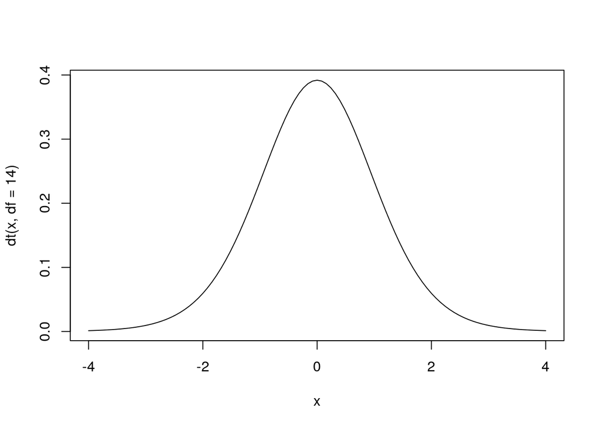

```r
curve( dt(x, df = 14), add = F, from = -4, to = 4)
```

- Si la muestra procede de una $N(60, \sigma^2)$, entonces lo más probable es que $t_0$ tome valores cercanos a 0, y con menor probabilidad tomará valores mayores que 3 o menores que -3.
- Con nuestra muestra, el estadístico $t_0$ es igual a:

```r
( t0 = (xm - 60)/(s/sqrt(15)) )
```

```
## [1] -3.884619
```

- Y se cumple que:

```r
( pvalor = pt(t0, df = 14) )
```

```
## [1] 0.0008254987
```

- Luego la probabilidad de que el estadístico $t_0$ tome un valor igual o menor a -3.88 es muy pequeña (8.254986610^{-4}). A esta probabilidad se le denomina **pvalor**. Tenemos dos opciones:
  - Considerar que el hormigon tiene resistencia igual a 60 y que nos ha tocado un muestra con una media *rara*, poco probable.
  - Considerar que la hipótesis nula no es correcta, es decir, el hormigón tiene resistencia inferior a 60.
- Se suele admitir que consideramos valores *raros* si la probabilidad de esos valores es inferior a 0.05.
- Luego admitimos que tenemos una probabilidad de equivocarnos igual a 0.05. Se denomina **nivel de significación del contraste** y se suele representar con la letra $\alpha$:

$$\alpha = P(rechazar \ H_0 | H_0 \ es \ cierta).$$

- Otra manera de resolver el contraste es calcular el cuantil de $\alpha$ y compararlo con $t_0$:

```r
qt(0.05, 14)
```

```
## [1] -1.76131
```

- Se tiene que $t_0=$ -3.8846195 < -1.7613101, luego pvalor < $\alpha$.

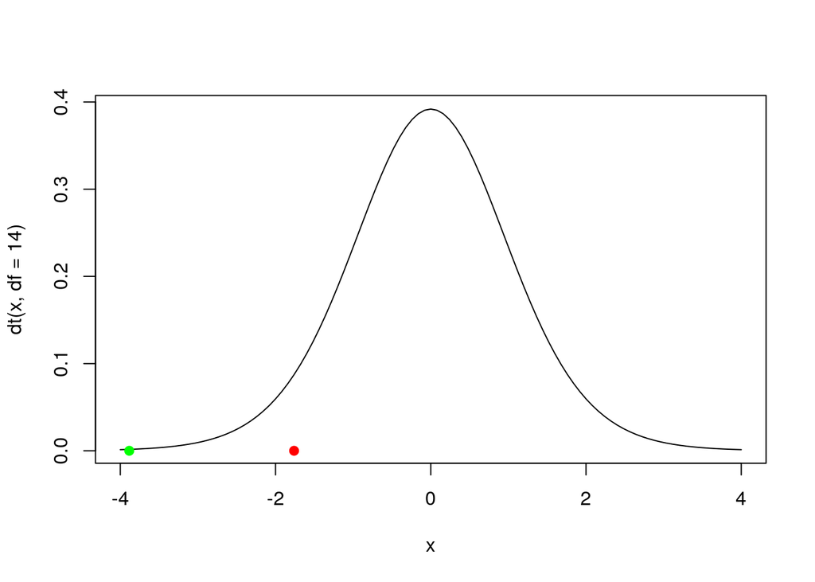

```r
curve( dt(x,df=14), add = F, from = -4, to = 4)
points(qt(0.05, df = 14),0, col = "red", pch = 19)
points(t0, 0, col = "green", pch = 19)
```

- En R, el contraste se resuelve utilizando la función *t.test()*:

```r
t.test(muestra, alternative = "less", mu = 60, conf.level = 0.95)
```

```
##
##  One Sample t-test
##
## data:  muestra
## t = -3.8846, df = 14, p-value = 0.0008255
## alternative hypothesis: true mean is less than 60
## 95 percent confidence interval:
##      -Inf 52.21286
## sample estimates:
## mean of x
##  45.75333
```

## 1.4 Contraste bilateral

- A veces el contraste se plantea como:

$$\begin{align}
H_0 \ & : \ \mu = 60 \\
H_1 \ & : \ \mu \neq 60
\end{align}$$

- El estadístico del contraste es el mismo que antes, que tomaba el valor $t_0=$ -3.8846195.
- En este caso, la zona de rechazo se reparte entre ambas colas de la distribución, $\alpha/2$ en cada cola. Por tanto, no se acepta la hipótesis nula si el estadístico del contraste toma valores:
  - menores que:

```r
qt(0.025,14)
```

```
## [1] -2.144787
```

```
- mayores que:
```

```r
qt(0.975,14)
```

```
## [1] 2.144787
```

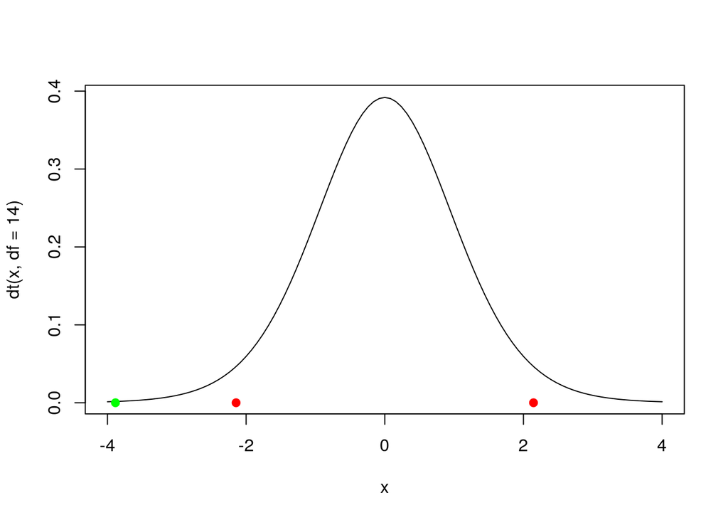

```r
curve( dt(x,df=14), add = F, from = -4, to = 4)
points(qt(0.025, df = 14),0, col = "red", pch = 19)
points(qt(0.975, df = 14),0, col = "red", pch = 19)
points(t0, 0, col = "green", pch = 19)
```

- El pvalor se calcula ahora como:

```r
( pvalor = 2*pt(t0,14) )
```

```
## [1] 0.001650997
```

- En R:

```r
t.test(muestra, alternative = "two.sided", mu = 60, conf.level = 0.95)
```

```
##
##  One Sample t-test
##
## data:  muestra
## t = -3.8846, df = 14, p-value = 0.001651
## alternative hypothesis: true mean is not equal to 60
## 95 percent confidence interval:
##  37.88742 53.61924
## sample estimates:
## mean of x
##  45.75333
```

# 2 Contraste para la varianza de la distribución normal

- Hemos obtenido una varianza muestral igual a $14.20^2$ = 201.64. Luego es pertinente plantear el siguiente contraste:

$$\begin{align}
H_0 \ & : \ \sigma^2 = 200 \\
H_1 \ & : \ \sigma^2 \neq 200
\end{align}$$

- Para resolver el contraste utilizamos la distribución en el muestreo:

$$\frac{(n-1)S^2}{\sigma^2} \sim \chi^2_{n-1}$$

- Si la hipótesis nula es cierta, $\sigma^2 = 200$, luego:

$$\frac{14S^2}{200} \sim \chi^2_{14}$$

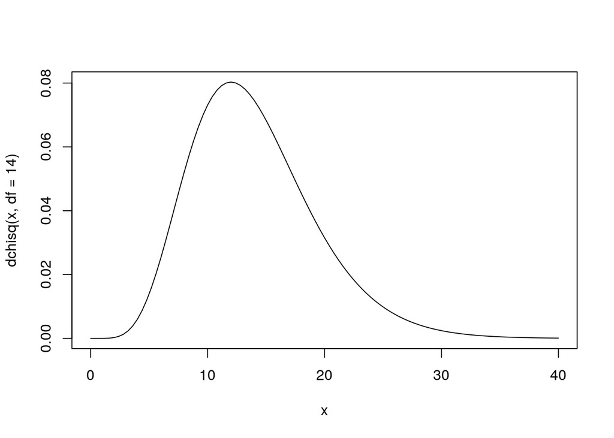

```r
curve( dchisq(x,df=14), add = F, from = 0, to = 40)
```

- El valor del estadístico del contraste con los datos de la muestra es:

```r
( chisq0 = 14*s^2/200 )
```

```
## [1] 14.12274
```

- Repartimos $\alpha$ entre las dos colas de la distribución:

```r
alfa = 0.05
qchisq(alfa/2, df = 14)
```

```
## [1] 5.628726
```

```r
qchisq(1-alfa/2, df = 14)
```

```
## [1] 26.11895
```

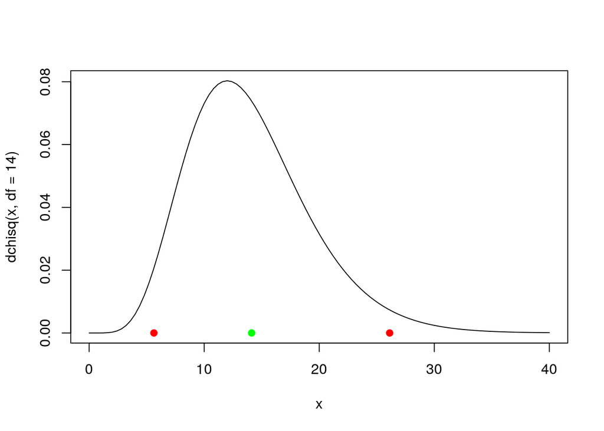

```r
curve( dchisq(x,df=14), add = F, from = 0, to = 40)
points(qchisq(alfa/2, df = 14),0,col = "red", pch = 19)
points(qchisq(1-alfa/2, df = 14),0,col = "red", pch = 19)
points(chisq0,0,col = "green", pch = 19)
```

- Por tanto, no rechazamos la hipótesis nula.

# 3 Contraste igualdad de medias

## 3.1 Planteamiento del problema

Se desea comparar dos tratamientos para reducir el nivel de colesterol en sangre. Se seleccionan 20 individuos y se asignan al azar a dos tipos de dieta, A y B. La reducción del nivel de colesterol tras dos meses de dieta son:

```r
A = c(51.3, 39.4, 26.3, 39.0, 48.1, 34.2, 69.8, 31.3, 45.2, 46.4)
B = c(29.6, 47.0, 25.9, 13.0, 33.1, 22.1, 34.1, 19.5, 43.8, 24.9)
data.frame(A,B)
```

```
##       A    B
## 1  51.3 29.6
## 2  39.4 47.0
## 3  26.3 25.9
## 4  39.0 13.0
## 5  48.1 33.1
## 6  34.2 22.1
## 7  69.8 34.1
## 8  31.3 19.5
## 9  45.2 43.8
## 10 46.4 24.9
```

```r
# numero de datos, media y desviacion tipica de la dieta A
( nA = length(A) )
```

```
## [1] 10
```

```r
( mA = mean(A) )
```

```
## [1] 43.1
```

```r
( sA = sd(A) )
```

```
## [1] 12.25479
```

```r
# numero de datos, media y desviacion tipica de la dieta B
( nB = length(B) )
```

```
## [1] 10
```

```r
( mB = mean(B) )
```

```
## [1] 29.3
```

```r
( sB = sd(B) )
```

```
## [1] 10.5704
```

```r
# numero total de datos
(n = nA + nB)
```

```
## [1] 20
```

## 3.2 Planteamiento del contraste

- Se considera el siguiente modelo para los datos:

$$\text{Dieta A: } y_{Ai} \sim N(\mu_A, \sigma^2)$$

$$\text{Dieta A: } y_{Bi} \sim N(\mu_B, \sigma^2)$$

- Luego suponemos que los datos tienen distinta media pero igual varianza.
- El estadístico del contraste es:

$$\frac{(\bar{y}_{A} - \bar{y}_{B}) - (\mu_A - \mu_B)}{s_R\sqrt{\frac{1}{n_A} + \frac{1}{n_B}}} \sim t_{n-2}$$

- donde:

$$s_R = \sqrt{ \frac{(n_A - 1)s_A^2 + (n_B - 1)s_B^2}{n - 2} }$$

- El contraste es:

$$\begin{align}
H_0 \ & : \ \mu_A = \mu_B \\
H_1 \ & : \ \mu_A \neq \mu_B
\end{align}$$

- Supongamos que la hipótesis nula es vedadera, luego:

$$t_0 = \frac{(\bar{y}_{A} - \bar{y}_{B})}{s_R\sqrt{\frac{1}{n_A} + \frac{1}{n_B}}} \sim t_{n-2}$$

- Si $\alpha = 0.05$, repartido entre las dos colas al ser un contraste bilateral:

```r
qt(0.025,df = n-2)
```

```
## [1] -2.100922
```

```r
qt(0.975,df = n-2)
```

```
## [1] 2.100922
```

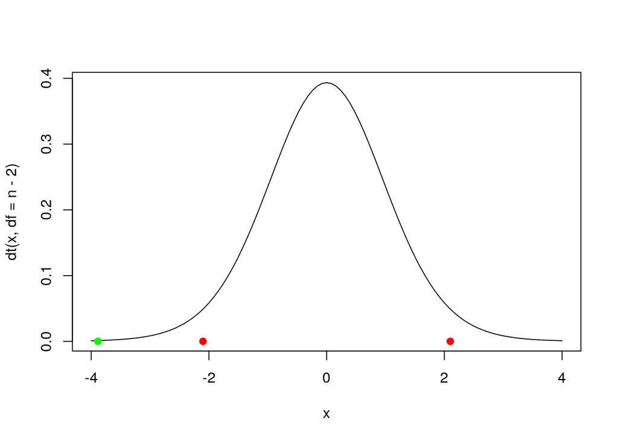

```r
curve( dt(x,df=n-2), add = F, from = -4, to = 4)
points(qt(0.025, df = n-2),0, col = "red", pch = 19)
points(qt(0.975, df = n-2),0, col = "red", pch = 19)
points(t0, 0, col = "green", pch = 19)
```

- El estadístico del contraste toma el valor:

```r
( sR = sqrt( ((nA-1)*var(A) + (nB-1)*var(B))/(n-2) ) )
```

```
## [1] 11.44363
```

```r
(t0 = (mean(A) - mean(B))/(sR*sqrt(1/nA+1/nB)))
```

```
## [1] 2.696499
```

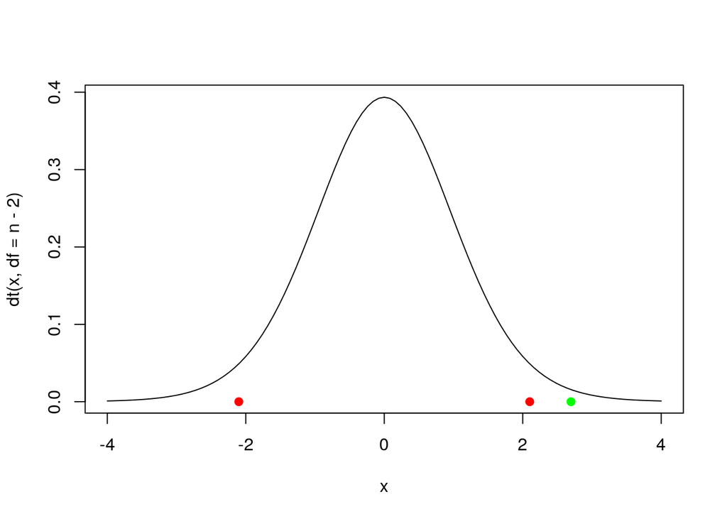

```r
curve( dt(x,df=n-2), add = F, from = -4, to = 4)
points(qt(0.025, df = n-2),0, col = "red", pch = 19)
points(qt(0.975, df = n-2),0, col = "red", pch = 19)
points(t0, 0, col = "green", pch = 19)
```

- Luego no se acepta $H_0$: las diestas tienen distinta reduccion media del colesterol.
- El pvalor del contraste es:

```r
( pvalor = 2*pt(t0, df = n-2, lower.tail = F) )
```

```
## [1] 0.01476099
```

- En R:

```r
t.test(A, B, var.equal = T)
```

```
##
##  Two Sample t-test
##
## data:  A and B
## t = 2.6965, df = 18, p-value = 0.01476
## alternative hypothesis: true difference in means is not equal to 0
## 95 percent confidence interval:
##   3.048013 24.551987
## sample estimates:
## mean of x mean of y
##      43.1      29.3
```

# 4 Contraste de igualdad de varianzas

- Hemos supuesto que la varianza de las dos diestas es la misma. Esta hipótesis se puede comprobar con otro contraste:

$$\begin{align}
H_0 \ & : \ \sigma_A^2 = \sigma_B^2 \\
H_1 \ & : \ \sigma_A^2 \neq \sigma_B^2
\end{align}$$

- No vamos a entrar en detalles, pero este contraste se puede resolver con:

```r
var.test(A, B)
```

```
##
##  F test to compare two variances
##
## data:  A and B
## F = 1.3441, num df = 9, denom df = 9, p-value = 0.6667
## alternative hypothesis: true ratio of variances is not equal to 1
## 95 percent confidence interval:
##  0.3338537 5.4113109
## sample estimates:
## ratio of variances
##           1.344093
```

# 5 Contraste $\chi^2$ de bondad de ajuste

## 5.1 Planteamiento del contraste

$$\begin{align}
H_0 \ & : \ X_i \sim f_X \\
H_1 \ & : \ X_i \nsim f_X
\end{align}$$

- Es decir, se contrasta si los datos tienen una distribución estadística determinada o no.
- El estadístico del contraste es:

$$\chi^2_0 = \sum_{k=1}^{K} \frac{(O_k - E_k)^2}{E_k} \sim \chi^2_{K-r-1}$$

- donde
  - $K$: es el número de intervalos en el que dividimos los datos.
  - $O_k$: numero de datos en el intervalo k.
  - $E_k$: numero de datos esperados en el intervalo k si $H_0$ fuese cierta.
  - $r$: numero de parámetros desconocidos de $f_X$.

## 5.2 Contraste $\chi^2$ de bondad de ajuste para la distribución uniforme

- Se ha lanzado 300 veces un dado y se han obtenido los resultados:

```r
Ok = c(49,59,49,51,43,49)
data.frame(num = 1:6, Ok)
```

```
##   num Ok
## 1   1 49
## 2   2 59
## 3   3 49
## 4   4 51
## 5   5 43
## 6   6 49
```

- Se puede afirmar que el dado esta desequilibrado ($\alpha=0.05$)?
- Si el dado está equilibrado, la probabilidad de obtener cada numero es la misma. Luego si lanzamos 300 veces el dado se deberían haber obtenido 50 veces cada numero.

```r
Ek = rep(50,6)
data.frame(num = 1:6, Ok, Ek)
```

```
##   num Ok Ek
## 1   1 49 50
## 2   2 59 50
## 3   3 49 50
## 4   4 51 50
## 5   5 43 50
## 6   6 49 50
```

- El valor del estadístico del contraste con nuestros datos es:

```r
( chisq0 = sum( (Ok - Ek)^2 / Ek ) )
```

```
## [1] 2.68
```

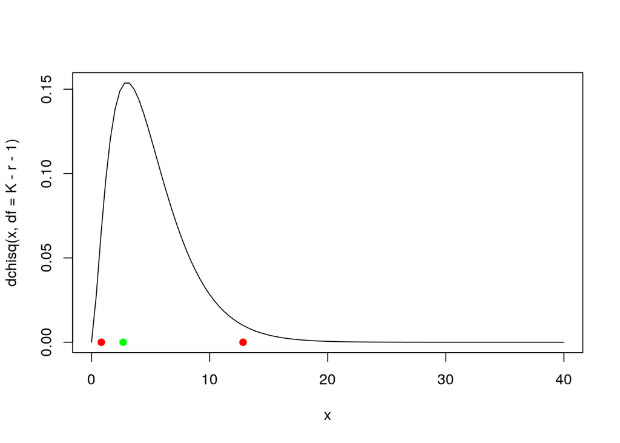

```r
K = 6
r = 0
alfa = 0.05
#
curve( dchisq(x, df = K-r-1), add = F, from = 0, to = 40)
points(qchisq(alfa/2, df = K-r-1),0,col = "red", pch = 19)
points(qchisq(1-alfa/2, df = K-r-1),0,col = "red", pch = 19)
points(chisq0,0,col = "green", pch = 19)
```

- En R:

```r
chisq.test(Ok, p = rep(1/6,6))
```

```
##
##  Chi-squared test for given probabilities
##
## data:  Ok
## X-squared = 2.68, df = 5, p-value = 0.7492
```

## 5.3 Contraste $\chi^2$ de bondad de ajuste para la distribución normal

- Vamos a comprobar la normalidad de la altura de los hombres:

```r
d <- read.table("body.dat.txt")
# peso
altura = d[,24]
# peso de los hombres
alturaH = altura[d[,25] == 1]
```

- Dividimos los datos en intervalos. El histograma lo hace automaticamente:

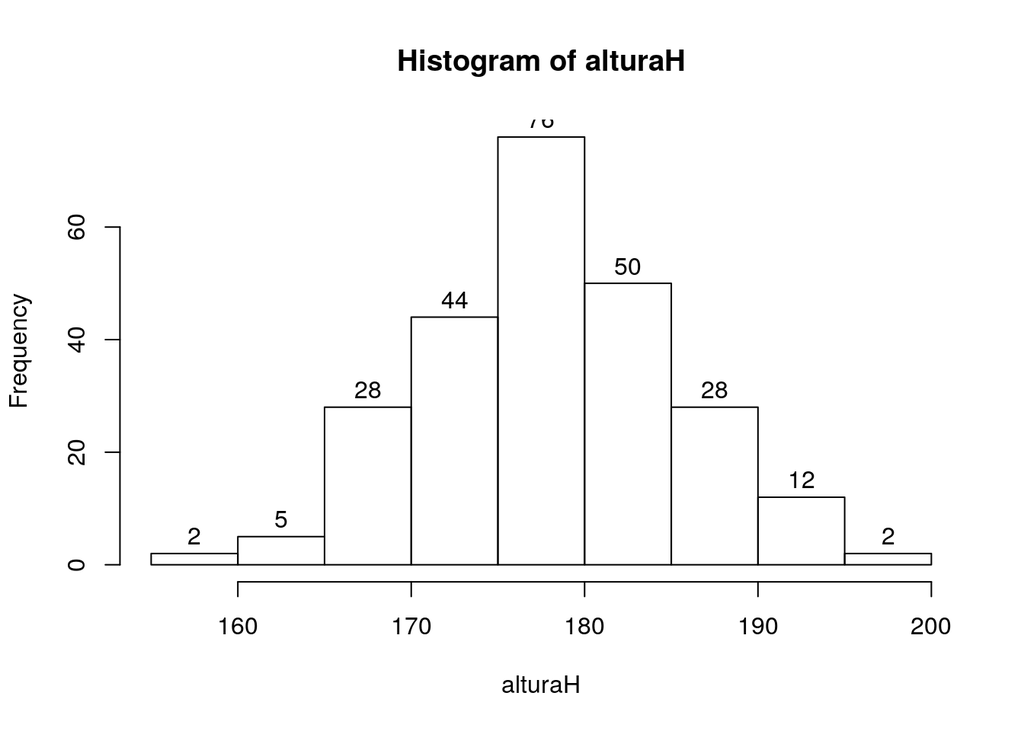

```r
h = hist(alturaH, breaks = seq(from = 155, to = 200, by = 5), label = T)
```

- Es recomendable que los intervalos tengan más de 5 datos. En caso contrario, agrupamos:

```r
intervalos = c(155,165,170,175,180,185,190,200)
h = hist(alturaH, breaks = intervalos, plot = F)
```

- Valores observados:

```r
( Ok = h$counts )
```

```
## [1]  7 28 44 76 50 28 14
```

- Valores esperados

```r
# H0 : X ~ N(mean(x), sd(x))
K = length(intervalos)
intervalos[1] = -1e6
intervalos[K] = 1e6
pE = rep(0,K-1) # probabilidades esperadas
for (k in 1:(K-1)){
  p1 = pnorm(intervalos[k], mean(alturaH), sd(alturaH))
  p2 = pnorm(intervalos[k+1], mean(alturaH), sd(alturaH))
  pE[k] = p2 - p1
}
( Ek = pE*sum(length(alturaH)) ) # datos esperados en cada intervalo
```

```
## [1]  9.389287 25.307700 52.041715 67.188345 54.473119 27.728868 10.870965
```

- Valor del estadistico del contraste:

```r
( chisq0 = sum( (Ok - Ek)^2 / Ek ) )
```

```
## [1] 4.563301
```

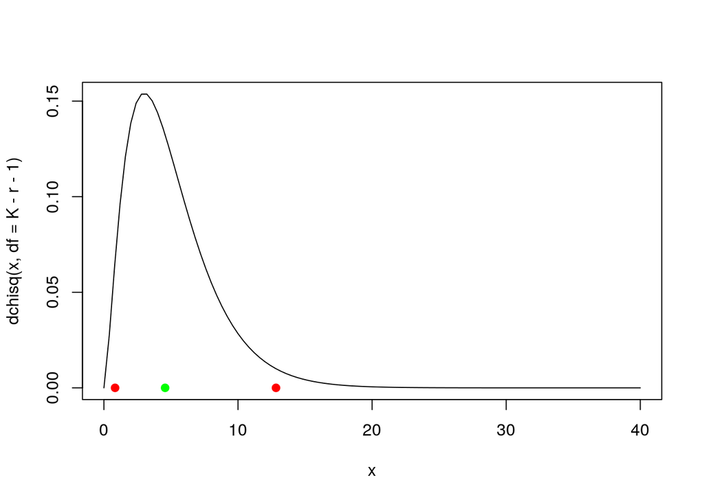

```r
r = 2
alfa = 0.05
#
curve( dchisq(x, df = K-r-1), add = F, from = 0, to = 40)
points(qchisq(alfa/2, df = K-r-1),0,col = "red", pch = 19)
points(qchisq(1-alfa/2, df = K-r-1),0,col = "red", pch = 19)
points(chisq0,0,col = "green", pch = 19)
```

- Luego no se puede rechazar la hipotesis nula (los datos son normales).
- En R:

```r
chisq.test(Ok, p = pE)
```

```
##
##  Chi-squared test for given probabilities
##
## data:  Ok
## X-squared = 4.5633, df = 6, p-value = 0.6009
```

- Ojo, en R los grados de libertad son K - 1.